# 改善注意力缺陷的功能性音乐特征分析

##### 于儿 <yue.fisher2025@gdhfi.com>

注意力缺陷多动障碍（Attention-Deficit/Hyperactivity Disorder, ADHD）作为一种全球高发的神经发育障碍，其核心临床表型涉及持续性注意力不集中、冲动控制受损以及工作记忆的缺陷 。我本人就是 ADHD 患者。在传统的临床干预中，以多巴胺和去甲肾上腺素再摄取抑制剂为主的药物治疗占据主导地位，然而药物干预往往伴随副作用，且在部分患者群体中效果受限 。随着认知神经科学与计算声学的交叉发展，基于听觉刺激的非药物干预策略，尤其是功能性音乐疗法，正逐渐成为前沿研究的焦点。一项 2024 年发表在《Journal of the American Academy of Child & Adolescent Psychiatry》上的分析明确指出，白噪声和粉红噪声对伴有高ADHD症状的个体在任务表现上具有显著的正向效应（效应量 $g = 0.249$），而同样的噪声却会削弱非 ADHD 人群的表现（效应量 $g = -0.212$）。

然而，并非所有类型的音乐或声音都能起到改善作用。传统的商业音乐、流行曲目乃至部分古典音乐，其创作初衷是为了唤起情感共鸣和吸引听觉注意力，迫使听者的注意力从当前的认知任务中转移到音乐本身 。因此，对于 ADHD 个体而言，旨在提高专注力的功能性音乐必然存在与一般音乐不同的特征。本分析将利用统计方法，从 Spotify 获取的音乐特征数据中，提取出能够改善专注度的功能性音乐的主要特征。

## 数据获取

我通过 Spotify API 获取了三类音乐的音频特征数据：

- Focus Music：改善专注度的功能性音乐
- Classical Music：古典音乐
- Pop Music：流行音乐

数据获取代码请参考 `spotify_data_retrieve.py`。

## 数据预处理

```python
# load libraries
import pandas as pd
import warnings

warnings.filterwarnings("ignore")
```

```python
# 加载 Focus Music 数据集
df_focus = pd.read_csv("dataset/Focus Music.csv")
df_focus.describe()
```

|  | energy | tempo | duration_ms | key | loudness | mode | speechiness | valence | instrumentalness | liveness | danceability | acousticness | time_signature |
| --- | --- | --- | --- | --- | --- | --- | --- | --- | --- | --- | --- | --- | --- |
| count | 1750.000000 | 1750.000000 | 1.750000e+03 | 1750.000000 | 1750.000000 | 1750.000000 | 1750.000000 | 1750.000000 | 1750.000000 | 1750.000000 | 1750.000000 | 1750.000000 | 1750.000000 |
| mean | 0.181263 | 103.292358 | 1.906652e+05 | 4.527429 | -25.094374 | 0.687429 | 0.061682 | 0.148378 | 0.797554 | 0.151883 | 0.308844 | 0.787793 | 3.733714 |
| std | 0.222634 | 33.354344 | 2.075724e+05 | 3.682371 | 8.536739 | 0.463674 | 0.073791 | 0.180171 | 0.269944 | 0.134354 | 0.203400 | 0.294445 | 0.776260 |
| min | 0.000000 | 30.651000 | 0.000000e+00 | 0.000000 | -53.446000 | 0.000000 | 0.026000 | 0.000010 | 0.000000 | 0.045300 | 0.057900 | 0.000000 | 1.000000 |
| 25% | 0.029150 | 73.855750 | 1.370740e+05 | 1.000000 | -30.521750 | 0.000000 | 0.039600 | 0.036800 | 0.817250 | 0.101000 | 0.156000 | 0.755250 | 3.000000 |
| 50% | 0.102000 | 96.656000 | 1.560000e+05 | 4.000000 | -24.390000 | 1.000000 | 0.044200 | 0.065500 | 0.904000 | 0.110000 | 0.216500 | 0.925000 | 4.000000 |
| 75% | 0.232750 | 129.748500 | 2.129618e+05 | 8.000000 | -19.173000 | 1.000000 | 0.053900 | 0.187000 | 0.948000 | 0.125000 | 0.477000 | 0.980000 | 4.000000 |
| max | 1.000000 | 220.160000 | 5.400149e+06 | 11.000000 | -3.398000 | 1.000000 | 0.936000 | 0.962000 | 1.000000 | 0.966000 | 0.919000 | 1.000000 | 5.000000 |

```python
pd.DataFrame([df_focus.median(numeric_only=True), df_focus.mean(numeric_only=True)], index=['Focus Music Median',  'Focus Music Mean']).T
```

|  | Focus Music Median | Focus Music Mean |
| --- | --- | --- |
| energy | 0.1020 | 0.181263 |
| tempo | 96.6560 | 103.292358 |
| duration_ms | 156000.0000 | 190665.198857 |
| key | 4.0000 | 4.527429 |
| loudness | -24.3900 | -25.094374 |
| mode | 1.0000 | 0.687429 |
| speechiness | 0.0442 | 0.061682 |
| valence | 0.0655 | 0.148378 |
| instrumentalness | 0.9040 | 0.797554 |
| liveness | 0.1100 | 0.151883 |
| danceability | 0.2165 | 0.308844 |
| acousticness | 0.9250 | 0.787793 |
| time_signature | 4.0000 | 3.733714 |

```python
# 加载 Classical Music 数据集
df_classical = pd.read_csv("dataset/Classical Music.csv")
df_classical.describe()
```

|  | energy | tempo | duration_ms | key | loudness | mode | speechiness | valence | instrumentalness | liveness | danceability | acousticness | time_signature |
| --- | --- | --- | --- | --- | --- | --- | --- | --- | --- | --- | --- | --- | --- |
| count | 695.000000 | 695.000000 | 695.000000 | 695.000000 | 695.000000 | 695.000000 | 695.000000 | 695.000000 | 695.000000 | 695.000000 | 695.000000 | 695.000000 | 695.000000 |
| mean | 0.161484 | 110.992837 | 164637.044604 | 4.833094 | -22.775669 | 0.647482 | 0.051603 | 0.426518 | 0.789831 | 0.141096 | 0.404144 | 0.931335 | 3.699281 |
| std | 0.146734 | 33.076719 | 107690.612356 | 3.598879 | 5.924531 | 0.478098 | 0.039057 | 0.292229 | 0.279267 | 0.104129 | 0.158693 | 0.136992 | 0.657641 |
| min | 0.000000 | 33.151000 | 0.000000 | 0.000000 | -41.150000 | 0.000000 | 0.029400 | 0.000000 | 0.000000 | 0.050000 | 0.070000 | 0.061400 | 1.000000 |
| 25% | 0.050200 | 82.947000 | 83000.000000 | 1.000000 | -27.277500 | 0.000000 | 0.040000 | 0.161000 | 0.840000 | 0.100000 | 0.287000 | 0.940000 | 3.000000 |
| 50% | 0.126000 | 108.820000 | 138000.000000 | 5.000000 | -22.599000 | 1.000000 | 0.042900 | 0.370000 | 0.905000 | 0.114000 | 0.380000 | 0.987000 | 4.000000 |
| 75% | 0.228500 | 134.075500 | 234071.500000 | 8.000000 | -18.620000 | 1.000000 | 0.051200 | 0.650000 | 0.930000 | 0.140000 | 0.510000 | 0.990000 | 4.000000 |
| max | 0.932000 | 210.039000 | 888000.000000 | 11.000000 | 0.117000 | 1.000000 | 0.560000 | 0.984000 | 0.994000 | 0.973000 | 0.893000 | 1.000000 | 5.000000 |

```python
# 加载 Pop Music 数据集
df_pop = pd.read_csv("dataset/Pop Music.csv")
df_pop.describe()
```

|  | energy | tempo | duration_ms | key | loudness | mode | speechiness | valence | instrumentalness | liveness | danceability | acousticness | time_signature |
| --- | --- | --- | --- | --- | --- | --- | --- | --- | --- | --- | --- | --- | --- |
| count | 774.000000 | 774.000000 | 7.740000e+02 | 774.000000 | 774.000000 | 774.000000 | 774.000000 | 774.000000 | 774.000000 | 774.000000 | 774.000000 | 774.000000 | 774.000000 |
| mean | 0.600935 | 118.926841 | 1.998673e+05 | 5.264858 | -9.649062 | 0.602067 | 0.075429 | 0.547052 | 0.283947 | 0.165209 | 0.665833 | 0.352680 | 3.844961 |
| std | 0.232972 | 28.802588 | 9.830569e+04 | 3.569075 | 5.465511 | 0.489788 | 0.070443 | 0.245088 | 0.400094 | 0.121581 | 0.139681 | 0.325068 | 0.484421 |
| min | 0.001610 | 53.376000 | 0.000000e+00 | 0.000000 | -35.920000 | 0.000000 | 0.023200 | 0.029200 | 0.000000 | 0.010500 | 0.159000 | 0.000000 | 1.000000 |
| 25% | 0.445250 | 97.864250 | 1.546318e+05 | 2.000000 | -13.480000 | 0.000000 | 0.037425 | 0.345250 | 0.000000 | 0.098825 | 0.580000 | 0.060000 | 4.000000 |
| 50% | 0.630000 | 118.010000 | 1.908200e+05 | 5.000000 | -7.932500 | 1.000000 | 0.050000 | 0.544500 | 0.000164 | 0.119000 | 0.680000 | 0.251000 | 4.000000 |
| 75% | 0.790000 | 132.626000 | 2.325092e+05 | 8.000000 | -5.423750 | 1.000000 | 0.082275 | 0.750000 | 0.810750 | 0.180000 | 0.761750 | 0.610000 | 4.000000 |
| max | 0.987000 | 206.934000 | 2.121692e+06 | 11.000000 | -1.310000 | 1.000000 | 0.610000 | 0.981000 | 0.977000 | 0.931000 | 0.962000 | 0.995000 | 5.000000 |

由于 Spotify 官方 API 已经废除了获取音乐特征的接口，在获取音乐特征时我使用了第三方接口 spotify-extended-audio-features-api，因此有些音乐没有获取到音频特征。在数据集上表现为音乐特征指标为 `NaN`。因此需要从数据集中剔除这些空数据。

```python
df_focus.dropna(subset=["energy"], inplace=True)
df_classical.dropna(subset=["energy"], inplace=True)
df_pop.dropna(subset=["energy"], inplace=True)
```

从数据集描述可以看出，有些音乐的时长 `duration_ms` 为 $0$，对于这些时长过短的音乐，我们选择直接剔除。

```python
MIN_DURATION = 60000 # 音乐最小时长 1 分钟
df_focus = df_focus[df_focus["duration_ms"] > MIN_DURATION]
df_classical = df_classical[df_classical["duration_ms"] > MIN_DURATION]
df_pop = df_pop[df_pop["duration_ms"] > MIN_DURATION]
```

```python
df_focus = df_focus.sample(n=800, random_state=2026)
df_focus.describe()
```

|  | energy | tempo | duration_ms | key | loudness | mode | speechiness | valence | instrumentalness | liveness | danceability | acousticness | time_signature |
| --- | --- | --- | --- | --- | --- | --- | --- | --- | --- | --- | --- | --- | --- |
| count | 800.000000 | 800.000000 | 8.000000e+02 | 800.000000 | 800.000000 | 800.000000 | 800.000000 | 800.000000 | 800.000000 | 800.000000 | 800.000000 | 800.000000 | 800.000000 |
| mean | 0.183265 | 102.695991 | 1.812486e+05 | 4.358750 | -25.295284 | 0.690000 | 0.063823 | 0.144909 | 0.787568 | 0.150065 | 0.307005 | 0.781221 | 3.700000 |
| std | 0.226400 | 33.285960 | 9.478268e+04 | 3.709076 | 8.673460 | 0.462783 | 0.076693 | 0.178235 | 0.280288 | 0.131909 | 0.198305 | 0.300285 | 0.786303 |
| min | 0.000000 | 30.651000 | 6.564100e+04 | 0.000000 | -52.026000 | 0.000000 | 0.026000 | 0.000010 | 0.000000 | 0.045300 | 0.057900 | 0.000000 | 1.000000 |
| 25% | 0.027575 | 73.826000 | 1.371610e+05 | 1.000000 | -30.659500 | 0.000000 | 0.039475 | 0.036700 | 0.812750 | 0.101000 | 0.155750 | 0.749750 | 3.000000 |
| 50% | 0.101500 | 93.161000 | 1.525290e+05 | 4.000000 | -24.803000 | 1.000000 | 0.044200 | 0.065450 | 0.899000 | 0.110000 | 0.220000 | 0.923000 | 4.000000 |
| 75% | 0.238000 | 129.775500 | 2.094620e+05 | 8.000000 | -19.367000 | 1.000000 | 0.053425 | 0.175000 | 0.947000 | 0.123000 | 0.470000 | 0.981000 | 4.000000 |
| max | 1.000000 | 220.160000 | 1.500030e+06 | 11.000000 | -3.398000 | 1.000000 | 0.753000 | 0.960000 | 0.999000 | 0.964000 | 0.850000 | 1.000000 | 5.000000 |

最后，将三个数据合并起来，得到最终的分析数据。

```python
# 为数据加上类型标签
df_focus['type'] = 'Focus Music'
df_classical['type'] = 'Classical Music'
df_pop['type'] = 'Pop Music'
# 合并数据
df = pd.concat([df_focus, df_classical, df_pop], axis=0)
df.describe()
```

|  | energy | tempo | duration_ms | key | loudness | mode | speechiness | valence | instrumentalness | liveness | danceability | acousticness | time_signature |
| --- | --- | --- | --- | --- | --- | --- | --- | --- | --- | --- | --- | --- | --- |
| count | 2172.000000 | 2172.000000 | 2.172000e+03 | 2172.000000 | 2172.000000 | 2172.000000 | 2172.000000 | 2172.000000 | 2172.000000 | 2172.000000 | 2172.000000 | 2172.000000 | 2172.000000 |
| mean | 0.324675 | 110.445078 | 1.893422e+05 | 4.857274 | -19.036615 | 0.642726 | 0.064186 | 0.361746 | 0.610138 | 0.152635 | 0.462187 | 0.671638 | 3.755525 |
| std | 0.293950 | 32.360215 | 9.770093e+04 | 3.650038 | 9.864411 | 0.479307 | 0.065011 | 0.294959 | 0.406687 | 0.122097 | 0.229006 | 0.367219 | 0.655622 |
| min | 0.000000 | 30.651000 | 6.200000e+04 | 0.000000 | -52.026000 | 0.000000 | 0.023200 | 0.000000 | 0.000000 | 0.010500 | 0.057900 | 0.000000 | 1.000000 |
| 25% | 0.064150 | 82.168500 | 1.350000e+05 | 1.000000 | -25.892000 | 0.000000 | 0.039300 | 0.081850 | 0.010875 | 0.100000 | 0.249000 | 0.316000 | 4.000000 |
| 50% | 0.220000 | 108.875500 | 1.739110e+05 | 5.000000 | -18.969500 | 1.000000 | 0.045400 | 0.302500 | 0.863000 | 0.111000 | 0.473500 | 0.873000 | 4.000000 |
| 75% | 0.562000 | 131.588750 | 2.276728e+05 | 8.000000 | -10.435000 | 1.000000 | 0.060000 | 0.593250 | 0.928000 | 0.143000 | 0.660000 | 0.983000 | 4.000000 |
| max | 1.000000 | 220.160000 | 2.121692e+06 | 11.000000 | 0.117000 | 1.000000 | 0.753000 | 0.984000 | 0.999000 | 0.973000 | 0.962000 | 1.000000 | 5.000000 |

## 数据分析

### 特征差异分析

我们先来看一下数据集的统计信息。我统计了每个音频类型下的每个音频特征的均值、中位数和方差。

```python
features = [
    "energy", "tempo", "loudness", "speechiness", "valence",
    "instrumentalness", "liveness", "danceability", "acousticness"
]

grouped = df.groupby("type")[features]

mean_df = grouped.mean().round(4)
median_df = grouped.median().round(4)
var_df = grouped.var().round(4)

print("=== 均值 ===")
print(mean_df)
print("\n=== 中位数 ===")
print(median_df)
print("\n=== 方差 ===")
print(var_df)
```

```
=== 均值 ===
                 energy     tempo  loudness  speechiness  valence  \
type
Classical Music  0.1581  109.9901  -22.7455       0.0516   0.4133
Focus Music      0.1833  102.6960  -25.2953       0.0638   0.1449
Pop Music        0.6019  118.8518   -9.6344       0.0744   0.5468

                 instrumentalness  liveness  danceability  acousticness
type
Classical Music            0.7912    0.1408        0.4087        0.9331
Focus Music                0.7876    0.1501        0.3070        0.7812
Pop Music                  0.2843    0.1646        0.6652        0.3534

=== 中位数 ===
                 energy     tempo  loudness  speechiness  valence  \
type
Classical Music  0.1200  107.1190  -22.5440       0.0432   0.3445
Focus Music      0.1015   93.1610  -24.8030       0.0442   0.0655
Pop Music        0.6300  117.5215   -7.8935       0.0500   0.5450

                 instrumentalness  liveness  danceability  acousticness
type
Classical Music            0.9070     0.112         0.387         0.987
Focus Music                0.8990     0.110         0.220         0.923
Pop Music                  0.0002     0.119         0.680         0.252

=== 方差 ===
                 energy      tempo  loudness  speechiness  valence  \
type
Classical Music  0.0218  1073.7217   33.9891       0.0013   0.0859
Focus Music      0.0513  1107.9551   75.2289       0.0059   0.0318
Pop Music        0.0542   832.6282   29.9485       0.0046   0.0602

                 instrumentalness  liveness  danceability  acousticness
type
Classical Music            0.0774    0.0118        0.0244        0.0175
Focus Music                0.0786    0.0174        0.0393        0.0902
Pop Music                  0.1601    0.0145        0.0195        0.1059
```

根据上面输出的均值、中位数和方差统计数据，我们可以看到三个音乐类型存在显著的差异：

#### Violin Plot 分析

通过 Violin Plot 可以更加直观地展示数据分布的差异。

```python
import seaborn as sns
import matplotlib.pyplot as plt

# 绘制单个指标的 Violin Plot
def single_feature_violin_plot(feature, df, ax, title=None):
    sns.violinplot(data=df,
                   x="type",
                   y=feature,
                   ax=ax,
                   palette="Set2",
                   inner=None,
                   cut=0)
    sns.boxplot(data=df,
                x="type",
                y=feature,
                ax=ax,
                width=0.15,
                palette="Set2",
                showcaps=True,
                showfliers=False,
                whiskerprops={"linewidth": 1})

    ax.set_title(title or feature.upper(), fontsize=11, fontweight="bold")
    ax.set_xlabel("")
    ax.set_ylabel(feature)
    ax.grid(axis="y", alpha=0.3)
```

```python
# 绘制所有指标的 Violin Plot
def draw_violin_plots():
    fig, axes = plt.subplots(3, 3, figsize=(24, 20))
    axes = axes.flatten()

    for i, feat in enumerate(features):
        single_feature_violin_plot(feat, df, axes[i])

    for j in range(len(features), len(axes)):
        axes[j].set_visible(False)

    fig.tight_layout()
    plt.show()
    plt.close(fig)
```

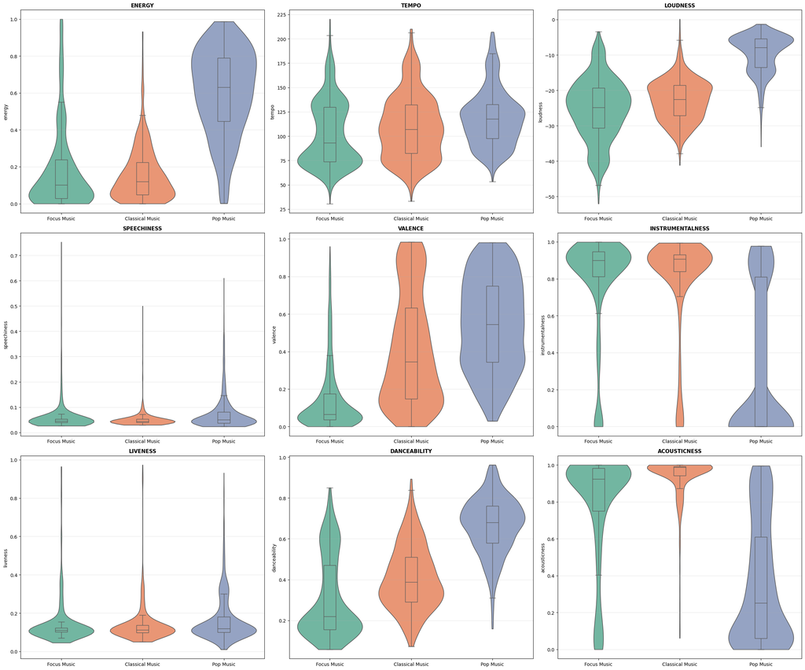

```python
draw_violin_plots()
```

从上图可以清晰看出：

- 三类的音乐在 `speechiness` 和 `liveness` 上的差异微小。
- 但在 `energy`，`instrumentalness` 和 `acousticness` 上，Pop Music 的分布形状与 Focus Music 和 Classical Music 完全不同，几乎时上下颠倒过来，呈现出两个极端。而 Focus Music 和 Classical Music 在这三个指标形态上非常接近。
- Pop Music 在 `loudness` 上显著高于 Focus Music 和 Classical Music。
- `valence` 和 `danceability` 上，三类的音乐存在明显差异，其中 Focus Music 的 `valence` 和 `danceability` 非常低，Classical Music 次之，Pop Music 最高。

### 相关性分析

我用相关性矩阵可视化三钟类别音乐中各种音频特征之间的相关性。

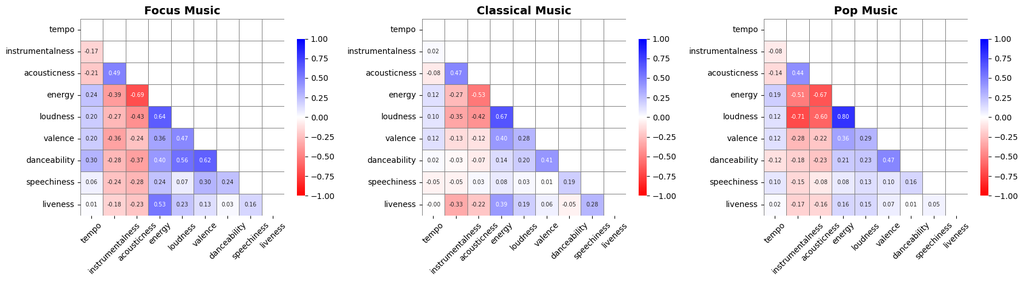

```python
import numpy as np
from matplotlib.colors import LinearSegmentedColormap
from scipy.cluster.hierarchy import linkage, leaves_list
from scipy.spatial.distance import squareform

types=["Focus Music", "Classical Music", "Pop Music"]

full_cor = df[features].corr(method="pearson")
d = 1 - np.abs(full_cor.values)
d = np.nan_to_num(d, nan=0.0)
np.fill_diagonal(d, 0)
link = linkage(squareform(d), method="complete")
order = leaves_list(link)
ordered_vars = [features[i] for i in order]

cmap_corr = LinearSegmentedColormap.from_list("rb", ["#FF0000", "#FFFFFF", "#0000FF"])

fig, axes = plt.subplots(1,
                         len(types),
                         figsize=(6 * len(types), 5),
                         squeeze=False)
for idx, topic_name in enumerate(types):
    topic_data = df[df["type"] == topic_name]
    if len(topic_data) == 0:
        warnings.warn(f"No data for topic: {topic_name}")
        continue
    cor_matrix = topic_data[features].corr(method="pearson")
    cor_matrix = cor_matrix.loc[ordered_vars, ordered_vars]

    mask = np.triu(np.ones_like(cor_matrix, dtype=bool))
    sns.heatmap(cor_matrix,
                mask=mask,
                cmap=cmap_corr,
                vmin=-1,
                vmax=1,
                annot=True,
                fmt=".2f",
                annot_kws={"size": 7},
                xticklabels=ordered_vars,
                yticklabels=ordered_vars,
                linewidths=0.5,
                linecolor="grey",
                ax=axes[0, idx],
                cbar_kws={"shrink": 0.8})
    axes[0, idx].set_title(topic_name, fontsize=14, fontweight="bold")
    axes[0, idx].tick_params(axis="x", rotation=45)
    axes[0, idx].tick_params(axis="y", rotation=0)

fig.tight_layout()
plt.show()
plt.close(fig)
```

从相关性矩阵可以看出：

- `loudness` 与 `energy`, `acousticness` 与 `instrumentalness`, `danceability` 与 `valence` 在三类音乐中都呈现出很高的正相关性。
- `energy`, `loudness`, `acousticness`, `instrumentalness` 在三类音乐中都呈现出很高的负相关性。
- Focus Music 中，指标之间的相关性普遍强于 Classical Music 和 Pop Music，其中 `loudness`, `valence` 和 `danceability` 之间存在很高的相关性。

### 综合呈现

我们可以价格类别差异与音频特征之间的相关性综合到一张图中。

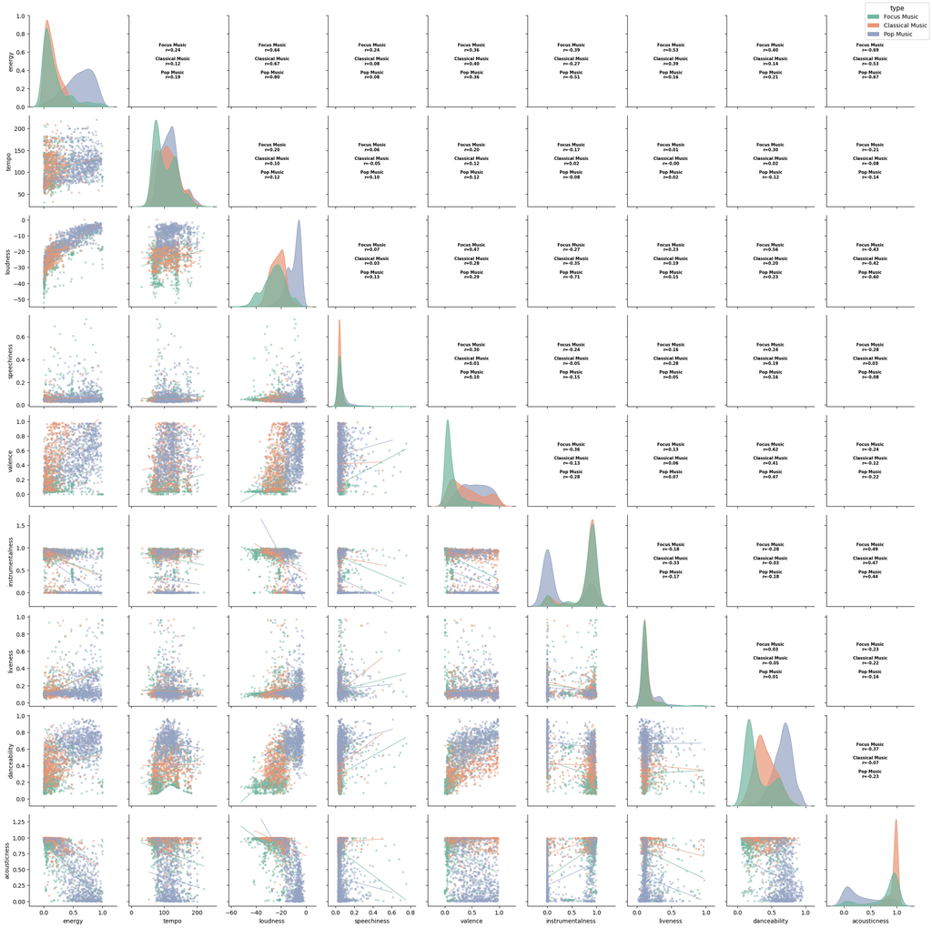

```python
from matplotlib.patches import Patch

pred_pair_colors = {
    "Focus Music": "#72B6A1",
    "Classical Music": "#E99675",
    "Pop Music": "#95A3C3",
}

pred_color_col = "type"
_pred_subset = ["Focus Music", "Classical Music", "Pop Music"]
pred_pair_df = df[features + [pred_color_col]].dropna()

def corr_func_pred(x, y, **kwargs):
    r = np.corrcoef(x, y)[0, 1]
    ax = plt.gca()
    label = kwargs.get("label", "")
    y_offsets = {"Focus Music": 0.65, "Classical Music": 0.5, "Pop Music": 0.35}
    yp = y_offsets.get(label, 0.5)
    ax.annotate(f"{label}\nr={r:.2f}", xy=(0.5, yp), xycoords="axes fraction",
                ha="center", va="center", fontsize=7, fontweight="bold")

def reg_func_pred(x, y, **kwargs):
    ax = plt.gca()
    color = kwargs.get("color", None)
    ax.scatter(x, y, alpha=0.4, s=8, color=color)
    if len(x) > 1:
        m, b = np.polyfit(x, y, 1)
        xline = np.linspace(x.min(), x.max(), 100)
        ax.plot(xline, m * xline + b, linewidth=0.8, color=color)

g_pair = sns.PairGrid(pred_pair_df, vars=features, hue=pred_color_col,
                       palette=pred_pair_colors, corner=False, diag_sharey=False)
g_pair.map_upper(corr_func_pred)
g_pair.map_lower(reg_func_pred)
g_pair.map_diag(sns.kdeplot, fill=True, alpha=0.7, common_norm=False,legend=False)
_pred_handles = [Patch(facecolor=pred_pair_colors[_label], edgecolor="none", label=_label) for _label in _pred_subset if _label in pred_pair_colors]
g_pair.figure.legend(handles=_pred_handles, title=pred_color_col,
                     loc="upper right", fontsize=10, title_fontsize=11)
plt.show()
plt.close(g_pair.figure)
```

## 机器学习验证

我们可以利用数据集训练一个可解释的分类模型，来验证前面分析出的特征差异是否在分类任务中去到决定作用。这里我选择 XGBoost 模型，因为它速度快，准确率高，且模型解释性好。

### Focus Music vs. Pop Music

根据前面的分析，Focus Music 和 Pop Music 在 `energy`, `instrumentalness`, `valence`, `acousticness` 和 `loudness` 上存在较大差异。我预测这些特征在分类任务中起着重要作用。

#### 模型训练

```
测试集准确率: 0.9268
ROC-AUC: 0.9720

分类报告:
              precision    recall  f1-score   support

 Focus Music       0.93      0.93      0.93       160
   Pop Music       0.93      0.92      0.93       154

    accuracy                           0.93       314
   macro avg       0.93      0.93      0.93       314
weighted avg       0.93      0.93      0.93       314

混淆矩阵:
[[149  11]
 [ 12 142]]
```

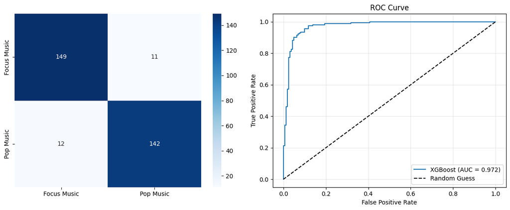

```python
from sklearn.model_selection import train_test_split
from sklearn.metrics import accuracy_score, classification_report, confusion_matrix, roc_auc_score, roc_curve
import xgboost as xgb

train_focus = df_focus[features]
train_classical = df_classical[features]
train_pop = df_pop[features]

X = np.vstack([train_focus, train_pop])
y = np.array([0]*len(train_focus) + [1]*len(train_pop))

# 划分训练集/测试集
X_train, X_test, y_train, y_test = train_test_split(X, y, test_size=0.2, random_state=2026, stratify=y)

# 训练XGBoost模型
model = xgb.XGBClassifier(
    objective='binary:logistic',   # 二元分类，输出概率
    eval_metric='logloss',
    max_depth=6,
    learning_rate=0.1,
    n_estimators=100,
    subsample=0.8,
    colsample_bytree=0.8,
    random_state=2026,
    use_label_encoder=False
)
model.fit(X_train, y_train)

# 预测与评估
y_pred = model.predict(X_test)
y_proba = model.predict_proba(X_test)[:, 1]

accuracy = accuracy_score(y_test, y_pred)
auc = roc_auc_score(y_test, y_proba)

print(f"测试集准确率: {accuracy:.4f}")
print(f"ROC-AUC: {auc:.4f}\n")
print("分类报告:")
print(classification_report(y_test, y_pred, target_names=['Focus Music', 'Pop Music']))

# 混淆矩阵
cm = confusion_matrix(y_test, y_pred)
print("混淆矩阵:")
print(cm)

# 可视化混淆矩阵和ROC曲线
fig, (ax1, ax2) = plt.subplots(1, 2, figsize=(12, 5))

sns.heatmap(cm, annot=True, fmt='d', cmap='Blues',
            xticklabels=['Focus Music', 'Pop Music'],
            yticklabels=['Focus Music', 'Pop Music'],
            ax=ax1)
plt.ylabel('truth')
plt.xlabel('prediction')
plt.title('Confusion Matrix')

fpr, tpr, thresholds = roc_curve(y_test, y_proba)
ax2.plot(fpr, tpr, label=f'XGBoost (AUC = {auc:.3f})')
ax2.plot([0, 1], [0, 1], 'k--', label='Random Guess')
ax2.set_xlabel('False Positive Rate')
ax2.set_ylabel('True Positive Rate')
ax2.set_title('ROC Curve')
ax2.legend(loc='lower right')
ax2.grid(alpha=0.3)

plt.tight_layout()
plt.show()
```

上面的数据表明，模型在 Focus Music 和 Pop Music 分类上的准确率和 AUC 都很高，说明模型在区分这两种音乐类型时表现良好。

两个类别的精确率、召回率、F1 均为 $0.93$，说明模型对 Focus Music 和 Pop Music 的识别能力几乎一致，没有明显的偏向。

- Focus Music：$160$ 个真实样本中，$149$ 个正确，$11$ 个被误判为 Pop Music（假负率 $6.9\%$）。
- Pop Music：$154$ 个真实样本中，$142$ 个正确，$12$ 个被误判为 Focus Music（假正率 $7.8\%$）。

#### 特征重要性

XGBoost 模型可以输出特征重要性，下面将特征重要性从高到低排序：

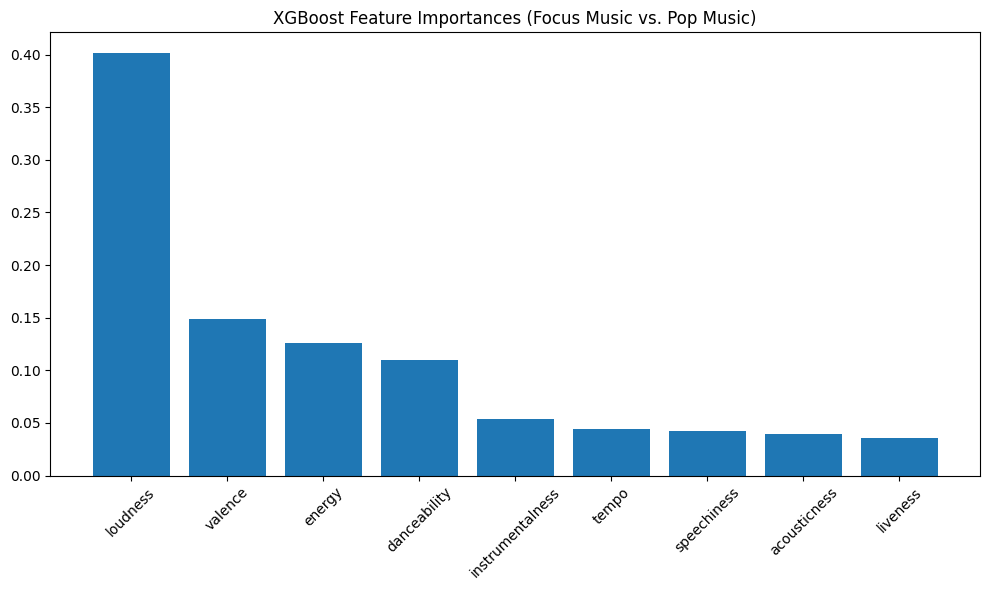

```python
importances = model.feature_importances_
indices = np.argsort(importances)[::-1]
plt.figure(figsize=(10,6))
plt.title("XGBoost Feature Importances (Focus Music vs. Pop Music)")
plt.bar(range(len(importances)), importances[indices], align='center')
plt.xticks(range(len(importances)), [features[i] for i in indices], rotation=45)
plt.tight_layout()
plt.show()
```

### Focus Music vs. Classical Music

再来看一下 Focus Music 和 Classical Music 的分类。根据前面的分析，Focus Music 和 Classical Music 在很多特征上非常相似，主要差异体现在 `valence` 和 `danceability`。我预测 `valence` 和 `danceability` 在分类任务中起着重要作用。

#### 模型训练

```
测试集准确率: 0.8505
ROC-AUC: 0.9378

分类报告:
              precision    recall  f1-score   support

 Focus Music       0.89      0.84      0.86       160
   Pop Music       0.80      0.87      0.83       121

    accuracy                           0.85       281
   macro avg       0.85      0.85      0.85       281
weighted avg       0.85      0.85      0.85       281

混淆矩阵:
[[134  26]
 [ 16 105]]
```

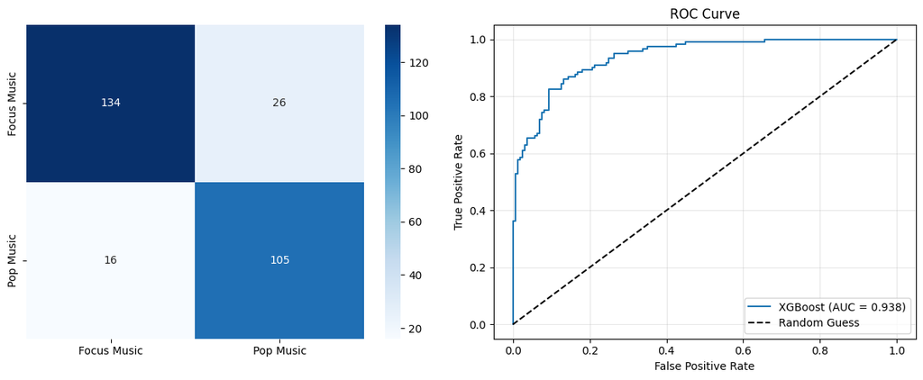

```python
X = np.vstack([train_focus, train_classical])
y = np.array([0]*len(train_focus) + [1]*len(train_classical))

# 划分训练集/测试集
X_train, X_test, y_train, y_test = train_test_split(X, y, test_size=0.2, random_state=2026, stratify=y)

# 训练XGBoost模型
model = xgb.XGBClassifier(
    objective='binary:logistic',   # 二元分类，输出概率
    eval_metric='logloss',
    max_depth=6,
    learning_rate=0.1,
    n_estimators=100,
    subsample=0.8,
    colsample_bytree=0.8,
    random_state=2026,
    use_label_encoder=False
)
model.fit(X_train, y_train)

# 预测与评估
y_pred = model.predict(X_test)
y_proba = model.predict_proba(X_test)[:, 1]

accuracy = accuracy_score(y_test, y_pred)
auc = roc_auc_score(y_test, y_proba)

print(f"测试集准确率: {accuracy:.4f}")
print(f"ROC-AUC: {auc:.4f}\n")
print("分类报告:")
print(classification_report(y_test, y_pred, target_names=['Focus Music', 'Pop Music']))

# 混淆矩阵
cm = confusion_matrix(y_test, y_pred)
print("混淆矩阵:")
print(cm)


# 可视化混淆矩阵和ROC曲线
fig, (ax1, ax2) = plt.subplots(1, 2, figsize=(12, 5))

sns.heatmap(cm, annot=True, fmt='d', cmap='Blues',
            xticklabels=['Focus Music', 'Pop Music'],
            yticklabels=['Focus Music', 'Pop Music'],
            ax=ax1)
plt.ylabel('truth')
plt.xlabel('prediction')
plt.title('Confusion Matrix')

fpr, tpr, thresholds = roc_curve(y_test, y_proba)
ax2.plot(fpr, tpr, label=f'XGBoost (AUC = {auc:.3f})')
ax2.plot([0, 1], [0, 1], 'k--', label='Random Guess')
ax2.set_xlabel('False Positive Rate')
ax2.set_ylabel('True Positive Rate')
ax2.set_title('ROC Curve')
ax2.legend(loc='lower right')
ax2.grid(alpha=0.3)

plt.tight_layout()
plt.show()
```

#### 特征重要性

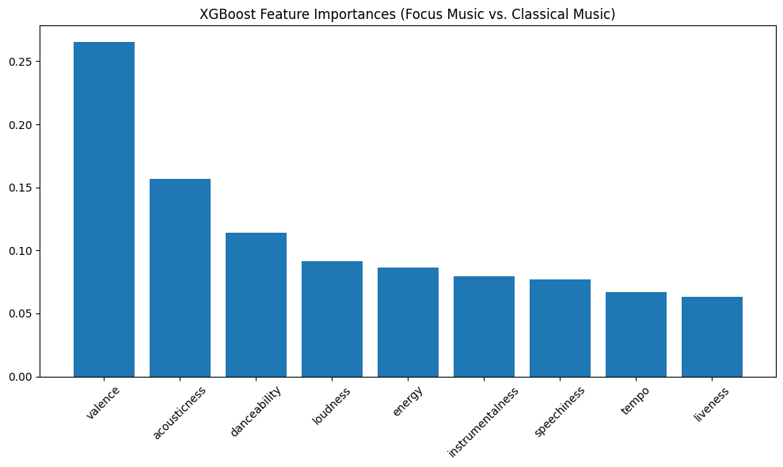

```python
importances = model.feature_importances_
indices = np.argsort(importances)[::-1]
plt.figure(figsize=(10,6))
plt.title("XGBoost Feature Importances (Focus Music vs. Classical Music)")
plt.bar(range(len(importances)), importances[indices], align='center')
plt.xticks(range(len(importances)), [features[i] for i in indices], rotation=45)
plt.tight_layout()
plt.show()
```

## 结论

本研究围绕功能性专注音乐（Focus Music）、古典音乐（Classical Music）与流行音乐（Pop Music）三类音乐的声学特征展开分析，旨在识别有助于改善 ADHD 个体注意力的音乐关键属性。综合描述性统计、分布可视化和基于XGBoost的分类实验，可以得出以下结论：

1. **功能性专注音乐具备高度一致的声学轮廓，与流行音乐几乎互为“镜像”。**

   在 Violin Plot 和均值对比中，Focus Music在能量（energy）、响度（loudness）、器乐性（instrumentalness）和原生性（acousticness）上的分布与 Pop Music 呈现上下颠倒的格局。Focus Music 整体表现为**低能量、低响度、高器乐性和高原生性**，而这恰好与 Pop Music 的高能量、高响度、强人声驱动与大量电子制作形成极端对立。这种“低唤醒、去人声、重原声”的声学配置，极可能是功能性专注音乐发挥认知辅助作用的基础。
2. **古典音乐与功能性专注音乐在多数维度上相近，但情绪效价是最关键的区分因子。**

   Focus Music 的内部特征相关性普遍强于另外两类，尤其在 `loudness`、`valence` 与 `danceability` 之间形成了较古典音乐和流行音乐更紧密的关联网络。这暗示功能性专注音乐并非随机生成的低唤醒纯音乐，而是经过了系统化的声学参数调控，以确保多维特征共同指向“去情绪化、去律动化”的听觉环境。

综合来看，本研究的结论可以用一个简洁的声学画像来概括理想的 ADHD 功能性专注音乐：

- 低能量（`energy` < $0.2$）
- 低响度（`loudness` < $-20$ dB）
- 极高器乐性（`instrumentalness` > $0.8$）
- 高原生性（`acousticness` > $0.8$）
- 低情绪效价（`valence` < $0.15$）
- 低舞蹈性（`danceability` < $0.30$）

在节奏方面，速度适中且不产生强烈节拍驱动（`tempo`约在 $90–110$ BPM区间）。这样的音乐在声学上接近于“安静的、无人声的、真实乐器演奏的、情绪抽离的背景声景”，能够在不抢夺注意力资源的前提下，为 ADHD 大脑提供稳定的感知底座，从而间接改善持续性注意力表现。